# Содержание:

## Предобработка данных

Видим что в одной базе лишнюю колонку, в справке к файлам указанно что в `internet` 4 колонки в файле их 5.

Удалим лишнюю колонку `Unnamed: 0` видимо получившуюся при сбросе индекса, создалась колонка с индексом.

```python
internet = internet.drop(columns=['Unnamed: 0'])
internet.head(5)
```

|  | id | mb_used | session_date | user_id |
| --- | --- | --- | --- | --- |
| 0 | 1000_0 | 112.95 | 2018-11-25 | 1000 |
| 1 | 1000_1 | 1052.81 | 2018-09-07 | 1000 |
| 2 | 1000_2 | 1197.26 | 2018-06-25 | 1000 |
| 3 | 1000_3 | 550.27 | 2018-08-22 | 1000 |
| 4 | 1000_4 | 302.56 | 2018-09-24 | 1000 |

В таблице `users` есть пропущенные данные в колонке `churn_date` дата прекращения пользования тарифом (если значение пропущено, то тариф ещё действовал на момент выгрузки данных), так как база за 2018 год запоним пропуски последним днем 2018 г. чтобы можно было проводить вычисления с этой колонкой создав таким образам отдельную группу. Для дальнейшего изменения типа данных так как это позволит нам производить вычисления связанное с датой, сделаем это через библиотеку `pandas`.

```python
users['churn_date'] = users['churn_date'].fillna('2018-12-31')


users['churn_date'] = pd.to_datetime(users['churn_date'], format='%Y-%m-%d')
users.info()
```

```
<class 'pandas.core.frame.DataFrame'>
RangeIndex: 498 entries, 0 to 497
Data columns (total 8 columns):
 #   Column      Non-Null Count  Dtype
---  ------      --------------  -----
 0   user_id     498 non-null    int64
 1   age         498 non-null    int64
 2   churn_date  498 non-null    datetime64[ns]
 3   city        498 non-null    object
 4   first_name  498 non-null    object
 5   last_name   498 non-null    object
 6   reg_date    498 non-null    object
 7   tariff      498 non-null    object
dtypes: datetime64[ns](1), int64(2), object(5)
memory usage: 31.2+ KB
```

Так же в других колонках с датами изменим тип данных через библиотеку `pandas`.

```python
calls['call_date'] = pd.to_datetime(calls['call_date'], format='%Y-%m-%d')
messages['message_date'] = pd.to_datetime(messages['message_date'], format='%Y-%m-%d')
internet['session_date'] = pd.to_datetime(internet['session_date'], format='%Y-%m-%d')
```

Добавим в колонку с месяцем чтобы потом групировать данные по месяцам:

```python
calls['month'] = calls['call_date'].dt.month
internet['month'] = internet['session_date'].dt.month
messages['month'] = messages['message_date'].dt.month
```

Приведем данные с учетом примечания для учета расходов по тарифам.

Для начала выведем 5 верхних строк по длительности звонков:

```python
calls['duration'].head(5)
```

```
0     0.00
1     0.00
2     2.85
3    13.80
4     5.18
Name: duration, dtype: float64
```

Округлим значения в большую сторону, с учетом того любая дополнительная секуда округляется до минуты. И выведем для проверки перые 5 строк:

```python
calls['duration'] = np.ceil(calls['duration'])
calls['duration'].head(5)
```

```
0     0.0
1     0.0
2     3.0
3    14.0
4     6.0
Name: duration, dtype: float64
```

Сделаем сводную таблицу длительности звонков, по абонентам, объеденияя данные по месяцам, выведем первые 10 строк:

```python
calls_month = (
    calls
    .pivot_table(index=['user_id','month'], values='duration', aggfunc='sum')
    .fillna(0)
              ).astype('int').reset_index()
calls_month.head(10)
```

|  | user_id | month | duration |
| --- | --- | --- | --- |
| 0 | 1000 | 5 | 159 |
| 1 | 1000 | 6 | 172 |
| 2 | 1000 | 7 | 340 |
| 3 | 1000 | 8 | 408 |
| 4 | 1000 | 9 | 466 |
| 5 | 1000 | 10 | 350 |
| 6 | 1000 | 11 | 338 |
| 7 | 1000 | 12 | 333 |
| 8 | 1001 | 11 | 430 |
| 9 | 1001 | 12 | 414 |

Сделаем сводную таблицу по количеству сообщений, по абонентам, объеденияя данные по месяцам, выведем первые 10 строк:

```python
messages_month = (
    messages
    .pivot_table(index=['user_id','month'], values='id', aggfunc='count')
    .fillna(0)
              ).astype('int').reset_index()
messages_month.rename({'id':'messages'}, axis=1, inplace=True)# переименование столбцов
messages_month.head(10)
```

|  | user_id | month | messages |
| --- | --- | --- | --- |
| 0 | 1000 | 5 | 22 |
| 1 | 1000 | 6 | 60 |
| 2 | 1000 | 7 | 75 |
| 3 | 1000 | 8 | 81 |
| 4 | 1000 | 9 | 57 |
| 5 | 1000 | 10 | 73 |
| 6 | 1000 | 11 | 58 |
| 7 | 1000 | 12 | 70 |
| 8 | 1002 | 6 | 4 |
| 9 | 1002 | 7 | 11 |

Сделаем сводную таблицу по интернет трафику, по абонентам, объеденияя данные по месяцам, выведем первые 10 строк:

```python
internet_month = (
    internet
    .pivot_table(index=['user_id','month'], values='mb_used', aggfunc='sum')
              ).reset_index()
internet_month.head(10)
```

|  | user_id | month | mb_used |
| --- | --- | --- | --- |
| 0 | 1000 | 5 | 2253.49 |
| 1 | 1000 | 6 | 23233.77 |
| 2 | 1000 | 7 | 14003.64 |
| 3 | 1000 | 8 | 14055.93 |
| 4 | 1000 | 9 | 14568.91 |
| 5 | 1000 | 10 | 14702.49 |
| 6 | 1000 | 11 | 14756.47 |
| 7 | 1000 | 12 | 9817.61 |
| 8 | 1001 | 11 | 18429.34 |
| 9 | 1001 | 12 | 14036.66 |

Округлим значения интернет трафика в большую сторону, с учетом примечания. И выведем для проверки перые 5 строк:

```python
internet_month['mb_used'] = np.ceil(internet_month['mb_used'] / 1024)
# и делим на 1024 чтобы получить гб потраченные абонентом учитываемые тарифом.
internet_month.rename({'mb_used':'gb_used'}, axis=1, inplace=True)
# переименование столбца из за перевода в гигобайты вместо мегобайтов
internet_month.head(10)
```

|  | user_id | month | gb_used |
| --- | --- | --- | --- |
| 0 | 1000 | 5 | 3.0 |
| 1 | 1000 | 6 | 23.0 |
| 2 | 1000 | 7 | 14.0 |
| 3 | 1000 | 8 | 14.0 |
| 4 | 1000 | 9 | 15.0 |
| 5 | 1000 | 10 | 15.0 |
| 6 | 1000 | 11 | 15.0 |
| 7 | 1000 | 12 | 10.0 |
| 8 | 1001 | 11 | 18.0 |
| 9 | 1001 | 12 | 14.0 |

Переведем так же мегобайты в гигобайты в таблице с тарифом.

```python
tariffs['mb_per_month_included'] = round(tariffs['mb_per_month_included'] / 1024)
tariffs.rename({'mb_per_month_included':'gb_per_month_included'}, axis=1, inplace=True)# переименование столбца из за перевода в гигобайты
tariffs.head()
```

|  | messages_included | gb_per_month_included | minutes_included | rub_monthly_fee | rub_per_gb | rub_per_message | rub_per_minute | tariff_name |
| --- | --- | --- | --- | --- | --- | --- | --- | --- |
| 0 | 50 | 15.0 | 500 | 550 | 200 | 3 | 3 | smart |
| 1 | 1000 | 30.0 | 3000 | 1950 | 150 | 1 | 1 | ultra |

Сведем все таблицы по тратам абонентов в одну таблицу, выведем первые 10 строк полученной таблицы:

```python
month_expenses = pd.merge(calls_month, messages_month, on=['user_id','month'], how='outer')
month_expenses = pd.merge(month_expenses, internet_month, on=['user_id','month'], how='outer')
month_expenses = pd.merge(month_expenses, users[['tariff','user_id']], on=['user_id'], how='outer')
month_expenses.head(10)
```

|  | user_id | month | duration | messages | gb_used | tariff |
| --- | --- | --- | --- | --- | --- | --- |
| 0 | 1000 | 5 | 159.0 | 22.0 | 3.0 | ultra |
| 1 | 1000 | 6 | 172.0 | 60.0 | 23.0 | ultra |
| 2 | 1000 | 7 | 340.0 | 75.0 | 14.0 | ultra |
| 3 | 1000 | 8 | 408.0 | 81.0 | 14.0 | ultra |
| 4 | 1000 | 9 | 466.0 | 57.0 | 15.0 | ultra |
| 5 | 1000 | 10 | 350.0 | 73.0 | 15.0 | ultra |
| 6 | 1000 | 11 | 338.0 | 58.0 | 15.0 | ultra |
| 7 | 1000 | 12 | 333.0 | 70.0 | 10.0 | ultra |
| 8 | 1001 | 11 | 430.0 | NaN | 18.0 | smart |
| 9 | 1001 | 12 | 414.0 | NaN | 14.0 | smart |

```python
month_expenses.shape[0]
```

```
3214
```

Посмотрим на пропуски в новой таблице:

```python
month_expenses.isna().sum()
```

```
user_id       0
month         0
duration     40
messages    497
gb_used      11
tariff        0
dtype: int64
```

Заполнии пустые значения нулем так как данные об использования услуги в этот месяц отсутствует.

```python
month_expenses[['duration','messages','gb_used']] = month_expenses[['duration','messages','gb_used']].fillna(0)
month_expenses.isna().sum()
```

```
user_id     0
month       0
duration    0
messages    0
gb_used     0
tariff      0
dtype: int64
```

Напишем функцию определяющию траты абонентов по месяцам и применем ее к нашей таблице создав новую колонку `expenses` с суммой трат абонентов:

```python
def expenses(duration, messages, gb_used, tariff):

    try:
        for i in range(len(tariffs)):
             if tariff == tariffs['tariff_name'][i]: #проверка тарифа

                dur = duration - tariffs['minutes_included'][i] #расхад пакета минут
                mes = messages - tariffs['messages_included'][i] #расхад пакета смс
                gb = gb_used - tariffs['gb_per_month_included'][i] #расхад пакета интернета


                if (dur > 0 and mes > 0 and gb > 0): # + + + перерасход всего
                    cost = (
                            dur * tariffs['rub_per_minute'][i]
                            + mes * tariffs['rub_per_message'][i]
                            + gb * tariffs['rub_per_gb'][i]
                            + tariffs['rub_monthly_fee'][i]
                           )
                    return cost
                if (dur <= 0 and mes > 0 and gb > 0): # - + + перерасход смс и интернета
                    cost = (
                           mes * tariffs['rub_per_message'][i]
                            + gb * tariffs['rub_per_gb'][i]
                            + tariffs['rub_monthly_fee'][i]
                           )
                    return cost
                if (dur <= 0 and mes <= 0 and gb > 0): # - - + перерасход интернета
                    cost = (
                            gb * tariffs['rub_per_gb'][i]
                            + tariffs['rub_monthly_fee'][i]
                           )
                    return cost
                if (dur <= 0 and mes > 0 and gb <= 0): # - + - перерасход смс
                    cost = (
                            mes * tariffs['rub_per_message'][i]
                            + tariffs['rub_monthly_fee'][i]
                           )
                    return cost
                if (dur <= 0 and mes <= 0 and gb <= 0): # - - - нет перерасхода всего
                    cost = tariffs['rub_monthly_fee'][i]
                    return cost
                if (dur > 0 and mes > 0 and gb <= 0): # + + - перерасход минут и смс
                    cost = (
                            dur * tariffs['rub_per_minute'][i]
                            + mes * tariffs['rub_per_message'][i]
                            + tariffs['rub_monthly_fee'][i]
                           )
                    return cost
                if (dur > 0 and mes <= 0 and gb <= 0): # + - - перерасход минут
                    cost = (
                            dur * tariffs['rub_per_minute'][i]
                            + tariffs['rub_monthly_fee'][i]
                           )
                    return cost
                if (dur > 0 and mes <= 0 and gb > 0): # + - + перерасход минут и интернета
                    cost = (
                            dur * tariffs['rub_per_minute'][i]
                            + gb * tariffs['rub_per_gb'][i]
                            + tariffs['rub_monthly_fee'][i]
                           )
                    return cost
    except:
        display('Ошибка проверить данные')

month_expenses['expenses'] = month_expenses.apply(lambda row : expenses(row['duration'], row['messages'], row['gb_used'], row['tariff']), axis = 1)
month_expenses.head(5)
```

|  | user_id | month | duration | messages | gb_used | tariff | expenses |
| --- | --- | --- | --- | --- | --- | --- | --- |
| 0 | 1000 | 5 | 159.0 | 22.0 | 3.0 | ultra | 1950.0 |
| 1 | 1000 | 6 | 172.0 | 60.0 | 23.0 | ultra | 1950.0 |
| 2 | 1000 | 7 | 340.0 | 75.0 | 14.0 | ultra | 1950.0 |
| 3 | 1000 | 8 | 408.0 | 81.0 | 14.0 | ultra | 1950.0 |
| 4 | 1000 | 9 | 466.0 | 57.0 | 15.0 | ultra | 1950.0 |

Хорошо, можем приступать к следущему шагу.

Проверим пропуски:

```python
month_expenses.isna().sum()
```

```
user_id     0
month       0
duration    0
messages    0
gb_used     0
tariff      0
expenses    0
dtype: int64
```

Отлично пропусков нет переходим к следущему шагу.

```python
# check
month_expenses.info()
```

```
<class 'pandas.core.frame.DataFrame'>
Int64Index: 3214 entries, 0 to 3213
Data columns (total 7 columns):
 #   Column    Non-Null Count  Dtype
---  ------    --------------  -----
 0   user_id   3214 non-null   int64
 1   month     3214 non-null   int64
 2   duration  3214 non-null   float64
 3   messages  3214 non-null   float64
 4   gb_used   3214 non-null   float64
 5   tariff    3214 non-null   object
 6   expenses  3214 non-null   float64
dtypes: float64(4), int64(2), object(1)
memory usage: 200.9+ KB
```

## Анализ данных

Посмотрим среднее значение по всем колонкам:

```python
month_expenses_mean = month_expenses.pivot_table(
    index='tariff', values=['duration','messages','gb_used','expenses'], aggfunc='median'
)
month_expenses_mean
```

| tariff | duration | expenses | gb_used | messages |
| --- | --- | --- | --- | --- |
| smart | 422.0 | 1023.0 | 17.0 | 28.0 |
| ultra | 518.0 | 1950.0 | 19.0 | 38.0 |

С учетом медианы за год абоненты не превышают пакет услуг, но в тарифе smart в отличие от ultra по оплате, расходы в smart почти в два раза больше базовой стоимости, вместо 550 р. выходит 1023 р. Видимо большой разброс по расходам пакетов, кто то разговаривает мало, а кто то много в среднем все укладывается в базовый пакет, но на стоимости превышение сказывается горазно значительнее.

- среднее длительность разговоров в месяц, в тарифе `smart` - 422 мин.
- среднее количество сообщений в месяц, в тарифе `smart` - 28 смс
- среднее интернет трафик в месяц, в тарифе `smart` - 17 гб.
- среднее длительность разговоров в месяц, в тарифе `ultra` - 518 мин.
- среднее количество сообщений в месяц, в тарифе `ultra` - 38 смс
- среднее интернет трафик в месяц, в тарифе `ultra` - 19 гб.
- средние траты в месяц, в тарифе `smart` - 1023 руб.
- средние траты в месяц, в тарифе `ultra` - 1950 руб.

Посчитаем дисперсию по тарифам:

```python
tariffs_list = ['smart', 'ultra']

for col in tariffs_list:
    print(col.center(len(col)+20))
    print(
        round(np.var(
            month_expenses.loc[month_expenses['tariff']==col,
            ['duration','messages','gb_used','expenses']], ddof=1))
    )
    print()
```

```
          smart
duration     36219.0
messages       797.0
gb_used         33.0
expenses    669786.0
dtype: float64

          ultra
duration    100874.0
messages      2285.0
gb_used         97.0
expenses    141517.0
dtype: float64
```

Посчитаем стандартное отклонение по тарифам:

```python
for col in tariffs_list:
    print(col.center(len(col)+20))
    print(
        round(np.std(
            month_expenses.loc[month_expenses['tariff']==col,
            ['duration','messages','gb_used','expenses']], ddof=1))
    )
    print()
```

```
          smart
duration    190.0
messages     28.0
gb_used       6.0
expenses    818.0
dtype: float64

          ultra
duration    318.0
messages     48.0
gb_used      10.0
expenses    376.0
dtype: float64
```

Посмотрим как менялось количество абонентов по месяцам:

```python
month_expenses.pivot_table(index='month',columns='tariff', values='user_id', aggfunc='count')
```

| tariff month | smart | ultra |
| --- | --- | --- |
| 1 | 34 | 9 |
| 2 | 58 | 24 |
| 3 | 77 | 37 |
| 4 | 112 | 55 |
| 5 | 141 | 67 |
| 6 | 164 | 84 |
| 7 | 201 | 91 |
| 8 | 235 | 107 |
| 9 | 260 | 115 |
| 10 | 294 | 123 |
| 11 | 316 | 134 |
| 12 | 337 | 139 |

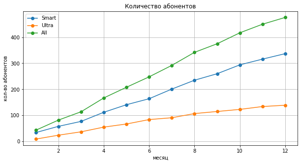

```python
users_mount = (
    month_expenses.pivot_table(index='month',columns='tariff', values='user_id', aggfunc='count')
    .plot( y='smart', style='o-',  grid=True, figsize=(10, 5))
)
(
    month_expenses.pivot_table(index='month',columns='tariff', values='user_id', aggfunc='count')
    .plot( y='ultra', style='o-',  grid=True, figsize=(10, 5), ax=users_mount)
);
(   month_expenses.pivot_table(index='month', values='user_id', aggfunc='count')
    .plot( y='user_id', style='o-',  grid=True, figsize=(10, 5), ax=users_mount, title='Количество абонентов')
);
users_mount.legend(['Smart', 'Ultra','All']);
#  Добавляем подписи к осям:
users_mount.set_xlabel('месяц')
users_mount.set_ylabel('кол-во абонентов')

plt.show()
```

В течении года количество абонентов заметно выросло примерно с 50 до 500 в общем, количество абонентов тарифа `smart` к концу года больше примерно в 2,5 раза больше абонентов тарифа `ultra`.

Посмотрим на гистрограммы, сколько длительность звонков, количество сообщений, объем трафика интернета и сумму расходав абонентов по месяцам с разделением по тарифам.

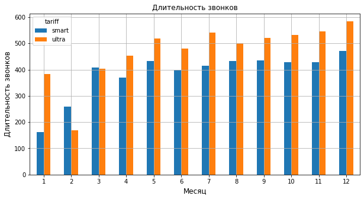

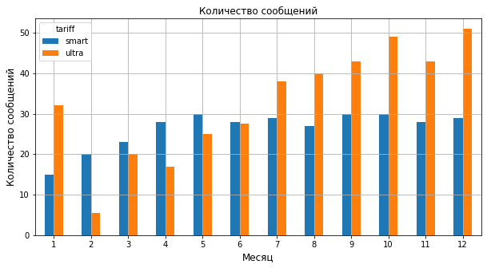

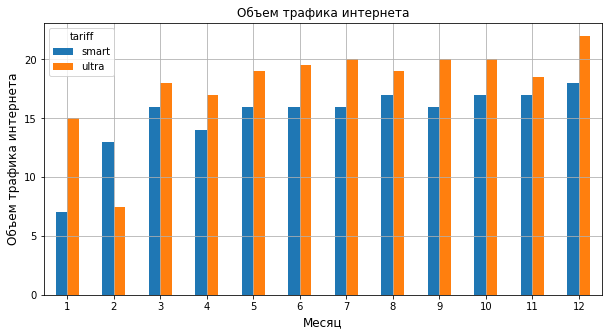

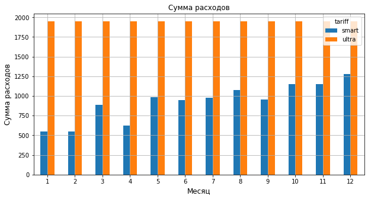

```python
group_col = ['duration','messages','gb_used','expenses']
group_name = ['Длительность звонков','Количество сообщений','Объем трафика интернета','Сумма расходов']

for i in range(len(group_col)):
    (
        month_expenses.pivot_table(index='month', columns='tariff', values=group_col[i], aggfunc='median')
        .plot( kind='bar',  grid=True, figsize=(10, 5), title=group_name[i])
    )

    plt.xticks(rotation=0)
    plt.xlabel('Месяц', size=12)
    plt.ylabel(group_name[i], size=12)
    plt.show()
```

- Есть рост длительности разговоров до мая, скорее всего это связано с ростом колисчество абонентов тем самым выборочная средняя стремится к генеральной совокупносте, после мая роста среднего уже нет, хотя количество абонентов все равно продолжается.
- По сообщениям, среднее значение, у тарифа `ultra`, растет с количеством абонентов если не брать выброс первого месяца из за малого количества абонентов в текущем месяце и концу года равняется около 50 сообщений. У тарифа `smart` рост идет только до мая далее средняя стабилизируется в значении 29 сообщений.
- По трафику интернета также рост только в нескольких первых месяцев вместе с ростом числа абонентов(до марта) далее среднее значение изменяется не сильно. К концк годасредее значение у тарифа `ultra` чуть больше 20гб, а у тарифа `smart` 18гб что является пререрасходом базового пакета в 15гб.
- Если смотреть среднее по расходам минут и сообщений, то нигде нет превышения пакета входящего в тариф, кроме трафика интернета в тарифе `smart` где средее за год превысило базовый пакет. По средним расходам в тарифе `ultra` все стабильно и в течении года нет превышений по ежемесячной плате в 1950 р. А вот в тарифе `smart` есть заметный рост в тратах с 550 р (базовая стоимость) в начале года и 1300 в конце.(в 2,3 раза выросли расходы у абонентов).

Посмотрим количество абонентов по тарифам и сумму трат по всем категориям:

```python
for col in tariffs_list:
    print('Количество абонентов в тарифе', col,':', len(month_expenses.loc[month_expenses['tariff'] == col,'user_id'].unique()))
    print()

month_expenses.pivot_table(index='tariff', values=['duration','messages','gb_used','expenses'], aggfunc='sum')
```

```
Количество абонентов в тарифе smart : 350

Количество абонентов в тарифе ultra : 148
```

| tariff | duration | expenses | gb_used | messages |
| --- | --- | --- | --- | --- |
| smart | 931577.0 | 2875351.0 | 36397.0 | 74413.0 |
| ultra | 518724.0 | 2039100.0 | 19202.0 | 48623.0 |

Видим что в сумме доходы от тарифа `smart` в 1,4 раза больше `ultra`, но при этом количество и абонентов тарифе `smart` в 2,4 раза больше тарифа `ultra`, так и средний доход от одного абонента у `ultra` выше чем у тарифа `smart`.

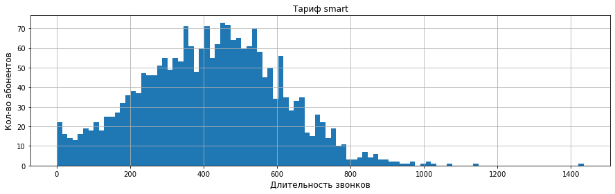

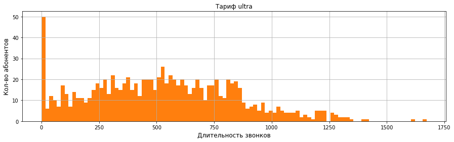

```python
color = ['#1f77b4','#ff7f0e']
for i in range(len(tariffs_list)):
    plt.figure(figsize=(15,4))
    month_expenses.loc[month_expenses['tariff'] == tariffs_list[i],'duration'].hist(bins=100, color = color[i])
    plt.title('Тариф '+tariffs_list[i])
    plt.xlabel('Длительность звонков', size=12)
    plt.ylabel('Кол-во абонентов', size=12)
    plt.show()
```

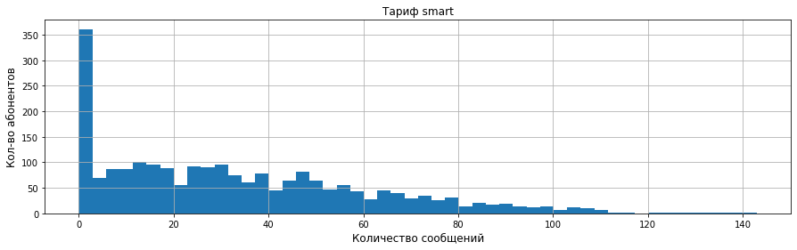

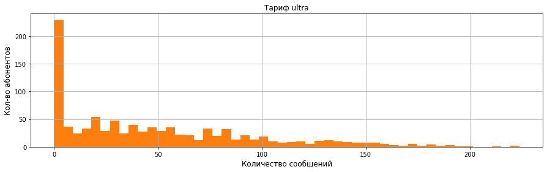

```python
for i in range(len(tariffs_list)):
    plt.figure(figsize=(15,4))
    month_expenses.loc[month_expenses['tariff'] == tariffs_list[i],'messages'].hist(bins=50, color = color[i])
    plt.title('Тариф '+tariffs_list[i])
    plt.xlabel('Количество сообщений', size=12)
    plt.ylabel('Кол-во абонентов', size=12)
    plt.show()
```

По построенным гистрограмма мы видим:

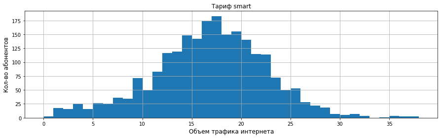

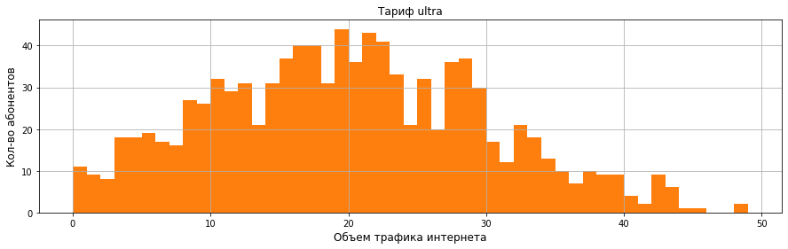

```python
bins_list = [38,49]
for i in range(len(tariffs_list)):
    plt.figure(figsize=(15,4))
    month_expenses.loc[month_expenses['tariff'] == tariffs_list[i],'gb_used'].hist(bins=bins_list[i], color = color[i])
    plt.title('Тариф '+tariffs_list[i])
    plt.xlabel('Объем трафика интернета', size=12)
    plt.ylabel('Кол-во абонентов', size=12)
    plt.show()
```

По построенным гистрограмма мы видим:

- По интернет трафику в тарифе `smart` график стремиться к нормальному распределению. Части абонентам также не хватает базового пакета доходя до 30 гб.(единичны до 38)
- По интернет трафику в тарифе `ultra` график с небольшим скосом вправо, большинство укладываются в 44 гб.(единичны до 49)

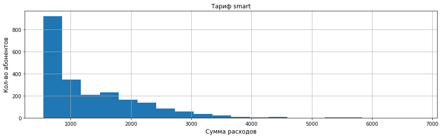

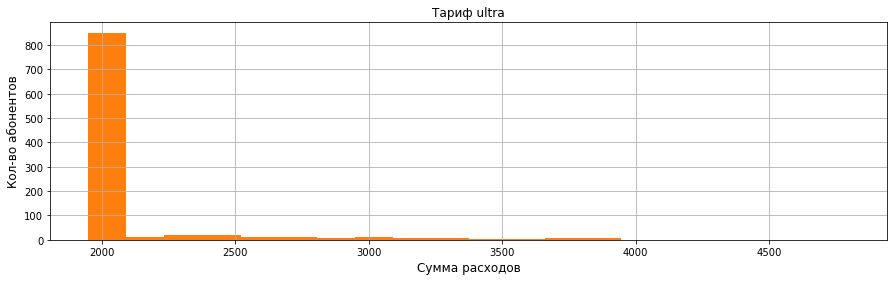

```python
for i in range(len(tariffs_list)):
    plt.figure(figsize=(15,4))
    (
        month_expenses.loc[month_expenses['tariff'] == tariffs_list[i],'expenses']
        .hist(bins=20, color = color[i])
    )
    plt.title('Тариф '+tariffs_list[i])
    plt.xlabel('Сумма расходов', size=12)
    plt.ylabel('Кол-во абонентов', size=12)
    plt.show()
```

И за больших скачков в базовой стоимости плохо видно другие значение, выведем дополнительный график без учета этих скачков.

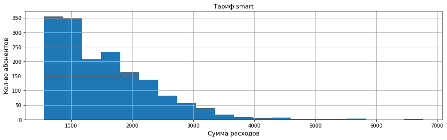

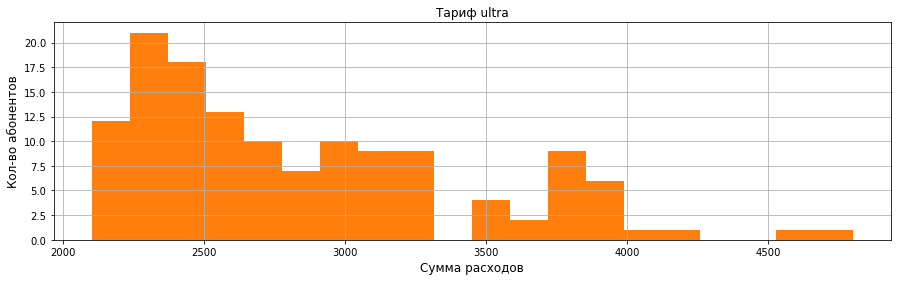

```python
limit_tariff = [550,1950]

for i in range(len(tariffs_list)):
    plt.figure(figsize=(15,4))
    (
        month_expenses.loc[(month_expenses['tariff'] == tariffs_list[i]) & (month_expenses['expenses'] > limit_tariff[i]),'expenses']
        .hist(bins=20, color = color[i])
    )
    plt.title('Тариф '+tariffs_list[i])
    plt.xlabel('Сумма расходов', size=12)
    plt.ylabel('Кол-во абонентов', size=12)
    plt.show()
```

По построенным гистрограмма мы видим:

- По тратам в тарифе `smart` видим скос вправо, с пиком в 550 р так как это базовая стоимость тарифа. Значительная часть абонентов не укладывается в базовую стоимость и доходит до 4000 р (единичные значения до 6500 р)
- По тратам в тарифе `ultra` так же скос вправо и график не такой равномерный возможно это сказывается разница в количестве. Большинство абонентов укладывается в базовую стоимость тарифа. Небольшая часть месячных трат доходит до 4000 р. И пара клиентов выбивалось до 4600-4700 р.

## Проверка гипотез

Перед проверкой гипотезы об отличии трат в зависимости региона(отличия Москвы от других регионов), напишем функцию для добавлении в нашу базу колонки с регионом, с двумя значениями: `Москва` или `Другой регион`

```python
month_expenses.head(5)
```

|  | user_id | month | duration | messages | gb_used | tariff | expenses |
| --- | --- | --- | --- | --- | --- | --- | --- |
| 0 | 1000 | 5 | 159.0 | 22.0 | 3.0 | ultra | 1950.0 |
| 1 | 1000 | 6 | 172.0 | 60.0 | 23.0 | ultra | 1950.0 |
| 2 | 1000 | 7 | 340.0 | 75.0 | 14.0 | ultra | 1950.0 |
| 3 | 1000 | 8 | 408.0 | 81.0 | 14.0 | ultra | 1950.0 |
| 4 | 1000 | 9 | 466.0 | 57.0 | 15.0 | ultra | 1950.0 |

```python
users.head(5)
```

|  | user_id | age | churn_date | city | first_name | last_name | reg_date | tariff |
| --- | --- | --- | --- | --- | --- | --- | --- | --- |
| 0 | 1000 | 52 | 2018-12-31 | Краснодар | Рафаил | Верещагин | 2018-05-25 | ultra |
| 1 | 1001 | 41 | 2018-12-31 | Москва | Иван | Ежов | 2018-11-01 | smart |
| 2 | 1002 | 59 | 2018-12-31 | Стерлитамак | Евгений | Абрамович | 2018-06-17 | smart |
| 3 | 1003 | 23 | 2018-12-31 | Москва | Белла | Белякова | 2018-08-17 | ultra |
| 4 | 1004 | 68 | 2018-12-31 | Новокузнецк | Татьяна | Авдеенко | 2018-05-14 | ultra |

```python
def region(row):

    user_id = row['user_id']

    for i in range(len(users['user_id'])):
        if user_id == users['user_id'][i]:
            if users['city'][i] == 'Москва':
                return 'Москва'
            else:
                return 'Другой регион'

month_expenses['region'] = month_expenses.apply(region,axis=1)
month_expenses.head(5)
```

|  | user_id | month | duration | messages | gb_used | tariff | expenses | region |
| --- | --- | --- | --- | --- | --- | --- | --- | --- |
| 0 | 1000 | 5 | 159.0 | 22.0 | 3.0 | ultra | 1950.0 | Другой регион |
| 1 | 1000 | 6 | 172.0 | 60.0 | 23.0 | ultra | 1950.0 | Другой регион |
| 2 | 1000 | 7 | 340.0 | 75.0 | 14.0 | ultra | 1950.0 | Другой регион |
| 3 | 1000 | 8 | 408.0 | 81.0 | 14.0 | ultra | 1950.0 | Другой регион |
| 4 | 1000 | 9 | 466.0 | 57.0 | 15.0 | ultra | 1950.0 | Другой регион |

Посмотрим на графиках как распределяются расходы по региона с делением по месяцам:

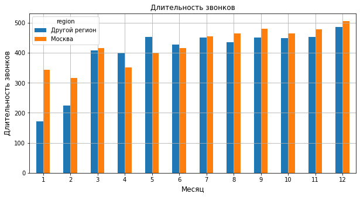

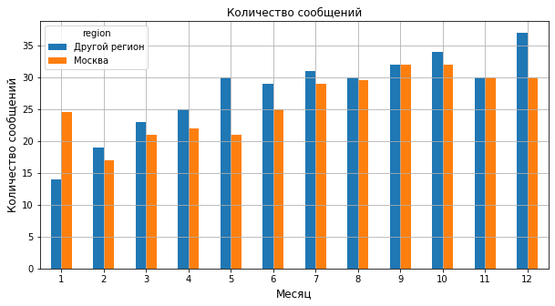

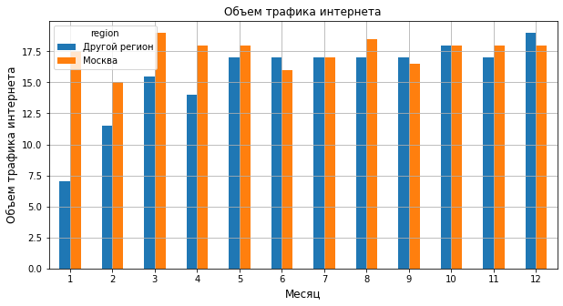

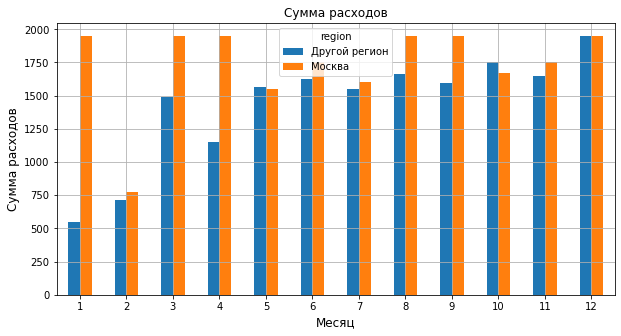

```python
for i in range(len(group_col)):
    (
        month_expenses.pivot_table(index='month',columns='region', values=group_col[i], aggfunc='median')
        .plot( kind='bar',  grid=True, figsize=(10, 5), title=group_name[i])
    )
    plt.xticks(rotation=0)
    plt.xlabel('Месяц', size=12)
    plt.ylabel(group_name[i], size=12)
    plt.show()
```

Нулевая гипотеза что тариф smart и ultra равны, альтернативная гипотеза что тарифы не равны(двухсторонняя):

```python
tariff_smart = month_expenses.loc[month_expenses['tariff']=='smart','expenses']
tariff_ultra = month_expenses.loc[month_expenses['tariff']=='ultra','expenses']

alpha = .05 #критический уровень статистической значимости

results_tariffs = st.ttest_ind(
    tariff_smart,
    tariff_ultra
)

print('p-значение:', results_tariffs.pvalue)

if results_tariffs.pvalue < alpha:
    print('Отвергаем нулевую гипотезу, что расходы по тарифам равны')
else:
    print('Не получилось отвергнуть нулевую гипотезу, что расходы по тарифам равны')
print()
print('cреднее по `smart`: ', round(tariff_smart.mean()))
print('cреднее по `ultra`: ', round(tariff_ultra.mean()))
```

```
p-значение: 1.4229814360764067e-160
Отвергаем нулевую гипотезу, что расходы по тарифам равны

cреднее по `smart`:  1290
cреднее по `ultra`:  2070
```

Отвергаем нулевую гипотезу что расходы у абонентов равны.

1,4 × 10^(−158)% такова вероятность допустить ошибку при отклонении нулевой гипотезы, так что мы переходим к альтернативной гипотизе.

Вторая часть, проверим нулевую гипотезу что расходы по регионам равны, альтернативная что расходны не равны.

```python
region_moscow = month_expenses.loc[month_expenses['region']=='Москва','expenses']
region_other = month_expenses.loc[month_expenses['region']=='Другой регион','expenses']

alpha = .05 #критический уровень статистической значимости

results_tariffs = st.ttest_ind(
    region_moscow,
    region_other
)

print('p-значение:', results_tariffs.pvalue)

if results_tariffs.pvalue < alpha:
    print('Отвергаем нулевую гипотезу, что расходы по регионам равны')
else:
    print('Не получилось отвергнуть нулевую гипотезу, что расходы по регионам равны')
print()
print('cреднее по Москве: ', round(region_moscow.mean()))
print('cреднее по другому региону: ', round(region_other.mean()))
```

```
p-значение: 0.5440152911670224
Не получилось отвергнуть нулевую гипотезу, что расходы по регионам равны

cреднее по Москве:  1547
cреднее по другому региону:  1525
```

Видим что отвергнуть нулевую гипотезу не получися, так как p-значение равно 54% что значительно превышает критический уровень статистической значимости в 5%.

### Посмотрим на отток клиентов течении года

```
Всего ушедших клиентов: 498

Ушедшие клиенты с тарифа `smart`: 350
Ушедшие клиенты с тарифа `ultra`: 148
```

| month tariff | 8 | 9 | 10 | 11 | 12 |
| --- | --- | --- | --- | --- | --- |
| smart | 1 | 1 | 5 | 6 | 337 |
| ultra | 1 | 2 | 4 | 2 | 139 |

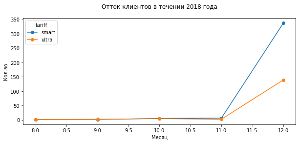

```python
df_users_departed = users.loc[users['churn_date'].notna()].copy()
# делаем копию таблицы по клиентов только с датой окончания оказывания услуг
df_users_departed['churn_date'] = pd.to_datetime(df_users_departed['churn_date'], format='%Y-%m-%d')
df_users_departed['month'] = df_users_departed['churn_date'].dt.month
# добавляем колоннку с месяцем
print()
print('Всего ушедших клиентов:', df_users_departed.shape[0])
print()
print('Ушедшие клиенты с тарифа `smart`:', df_users_departed.query('tariff == "smart"').shape[0])
print('Ушедшие клиенты с тарифа `ultra`:', df_users_departed.query('tariff == "ultra"').shape[0])

departed_users = df_users_departed.pivot_table(index='tariff', columns='month', values='user_id', aggfunc='count')

(departed_users
 .T
 .plot(kind='line', figsize=(10,4),  style = 'o-')
)

plt.title('Отток клиентов в течении 2018 года'+ "\n")
plt.xlabel('Месяц')
plt.ylabel('Кол-во');
# выводим график оттока

departed_users
```

## Выводы

3) В среднем на одного абонента доход выше у тарифа `ultra` **2071 р.** против **1291 р.** у `smart`.

6) Рекомендация так как среднии доход от тарифа `ultra` выше, нужно скорректировать рекламный бюджет чтобы привлечь дополнительных клиентов.